# Additional Materials 01 :

Summary Statistics

[Grace Smith-Vidaurre](http://smith-vidaurre.com/)<sup>1*</sup>, [Valeria Perez](http://wrightbehaviorlab.org)<sup>1</sup>, [Timothy F. Wright](http://wrightbehaviorlab.org)<sup>1</sup> <sup>1</sup>Department of Biology, New Mexico State University *Corresponding author (gsvidaurre@gmail.com)

02 September 2020

Invasive range calls were taken through a pre-processing workflow similar to previously published native range calls<sup>[1]</sup>. Previously published invasive range calls for 2004 were provided by `Susannah Bhurman-Deever`<sup>[2]</sup>, and were pre-processed in the same way. See supplementary methods for details on pre-processing steps. The package `warbleR`<sup>[3]</sup> was used for pre-processing, making extended selection tables, and downstream analyses.

We generated summary statistics of the combined native and invasive range datasets across the individual and site social scales, then analyzed differences in nest estimates between ranges. See supplementary methods for more information on how we defined social scales.

```r
rm(list = ls())

X <- c("warbleR", "pbapply", "Rraven", "tidyverse", "ggplot2", "data.table", "lubridate", "pracma", "knitr", "effsize", "coin")
invisible(lapply(X, library, character.only = TRUE))

path <- "/media/owner/MYIOPSITTA/R/VocalLearning_PostInvasion/Data"

seed <- 401

cores <- parallel::detectCores() - 2
```

Read in extended selection table that contains metadata and wave objects for pre-processed native and invasive range calls across the individual and site scales.

```r
nat_inv_est <- readRDS(file.path(path, "nat_inv_indiv_site_EST.RDS"))
glimpse(nat_inv_est)
```

```
## Rows: 1,596
## Columns: 26
## $ sound.files          <chr> "2017_07_17_EMBR_INDIV-RAW_MZ000199_1.WAV", "201…
## $ selec                <dbl> 1, 1, 1, 1, 1, 1, 1, 1, 1, 1, 1, 1, 1, 1, 1, 1, …
## $ start                <dbl> 0.05, 0.05, 0.05, 0.05, 0.05, 0.05, 0.05, 0.05, …
## $ end                  <dbl> 0.2646363, 0.2310324, 0.2509257, 0.2378781, 0.22…
## $ date                 <date> 2017-07-17, 2017-07-17, 2017-07-17, 2017-07-17,…
## $ range                <fct> Native, Native, Native, Native, Native, Native, …
## $ social_scale         <chr> "Individual", "Individual", "Individual", "Indiv…
## $ site                 <chr> "EMBR", "EMBR", "EMBR", "EMBR", "EMBR", "EMBR", …
## $ Bird_ID              <chr> "NAT-RAW", "NAT-RAW", "NAT-RAW", "NAT-RAW", "NAT…
## $ lat                  <dbl> -34.44437, -34.44437, -34.44437, -34.44437, -34.…
## $ lon                  <dbl> -57.72845, -57.72845, -57.72845, -57.72845, -57.…
## $ Visual_quality_score <fct> H, M, H, H, M, M, M, H, M, H, H, H, M, M, H, H, …
## $ Overlapping_signal   <fct> N, N, N, N, N, N, N, N, N, N, N, N, N, N, N, N, …
## $ Truncated            <chr> "N", "N", "N", "N", "N", "N", "N", "N", "N", "N"…
## $ tailored             <fct> y, y, y, y, y, y, y, y, y, y, y, y, y, y, y, y, …
## $ prev_SNR             <dbl> 20.10350, 14.90409, 18.55063, 18.49727, 18.74672…
## $ SNR_margin_works     <chr> "Y", "Y", "Y", "Y", "Y", "Y", "Y", "Y", "Y", "Y"…
## $ SNR_before_only      <chr> NA, NA, NA, NA, NA, NA, NA, NA, NA, NA, NA, NA, …
## $ old.sound.file.name  <chr> "2017_07_17_EMBR_INDIV-RAW_MZ000199_1.WAV", "201…
## $ SNR                  <dbl> 23.45415, 22.14815, 15.36660, 19.25200, 21.86770…
## $ region               <chr> "West", "West", "West", "West", "West", "West", …
## $ country              <chr> "Uruguay", "Uruguay", "Uruguay", "Uruguay", "Uru…
## $ site_year            <chr> "EMBR_2017", "EMBR_2017", "EMBR_2017", "EMBR_201…
## $ year                 <chr> "2017", "2017", "2017", "2017", "2017", "2017", …
## $ dept_state           <chr> "Colonia", "Colonia", "Colonia", "Colonia", "Col…
## $ invasive_city        <chr> NA, NA, NA, NA, NA, NA, NA, NA, NA, NA, NA, NA, …
```

Write out the selection table (e.g. the data frame associated with the extended selection table) for sharing purposes. Also write out the .wav files associated with the extended selection table. Each .wav file corresponds to a cut of the original recording that contains the selected call and a small margin around the given call (with the exception of 2004 calls, which were obtained for this study as cuts). The reason for writing out the data in this way is that the .RDS file saved above will not be compatible with all versions of R in the future.

```r
# Write out the selection table as a .csv
write.csv(nat_inv_est, file.path(path, "nat_inv_indiv_site_seltbl.csv"), row.names = FALSE)

# Write out the .wav files to a directory in which I'm using to compile data for sharing

# Access the wave objects
length(attr(nat_inv_est, "wave.objects"))
attr(nat_inv_est, "wave.objects")[1]

# Get the .wav objects and their respective filenames in order to write these out as separate .wav files
wavs <- attr(nat_inv_est, "wave.objects")
wav_nms <- names(attr(nat_inv_est, "wave.objects"))

# x <- 1 testing
tmp_path <- "/home/owner/Desktop/MANUSCRIPTS/SimplerCalls_PostInvasion/SHARE_DATA/Data/pre-processed_calls"
invisible(pblapply(1:length(wavs), function(x){
  writeWave(wavs[[x]], filename = file.path(tmp_path, wav_nms[x]), extensible = FALSE)
}))
```

# Individual scale

Total number of repeatedly sampled individual calls across ranges.

```r
nat_inv_est %>%
  filter(social_scale == "Individual") %>%
  group_by(range) %>%
  count() %>%
  kable(align = rep("c", 2))
```

| range | n |
| --- | --- |
| Native | 97 |
| Invasive | 132 |

Number of known repeatedly sampled individuals across ranges.

```r
nat_inv_est %>%
  filter(social_scale == "Individual") %>%
  group_by(range) %>%
  summarise(count = n_distinct(Bird_ID)) %>%
  kable(align = rep("c", 2))
```

| range | count |
| --- | --- |
| Native | 8 |
| Invasive | 9 |

Number of sites at which we sampled known repeatedly sampled individuals across ranges.

```r
nat_inv_est %>%
  filter(social_scale == "Individual") %>%
  group_by(range) %>%
  summarise(count = n_distinct(site)) %>%
  kable(align = rep("c", 2))
```

| range | count |
| --- | --- |
| Native | 3 |
| Invasive | 7 |

Number of calls per known repeatedly sampled individual across ranges, and recording dates. Used for supplementary table 4.

```r
nat_inv_est %>%
  filter(social_scale == "Individual") %>%
  group_by(range, Bird_ID, lat, lon, site, dept_state) %>%
  count() %>%
  arrange(range, site) %>%
  inner_join(
    nat_inv_est %>%
      filter(social_scale == "Individual") %>%
      group_by(range, Bird_ID) %>%
      distinct(date),
    by = c("range", "Bird_ID")
  ) %>%
  ungroup() %>%
  dplyr::mutate(
    lat = round(lat, 3),
    lon = round(lon, 3)
  ) %>%
  dplyr::select(Bird_ID, site, dept_state, lat, lon, n, date) %>%
  kable(align = rep("c", 4))
```

| Bird_ID | site | dept_state | lat | lon | n | date |
| --- | --- | --- | --- | --- | --- | --- |
| NAT-AAT | 1145 | Colonia | -34.376 | -57.500 | 12 | 2017-07-29 |
| NAT-UM1 | 1145 | Colonia | -34.375 | -57.502 | 25 | 2017-07-28 |
| NAT-UM2 | 1145 | Colonia | -34.375 | -57.502 | 23 | 2017-07-24 |
| NAT-UM3 | 1145 | Colonia | -34.375 | -57.502 | 5 | 2017-07-24 |
| NAT-UM4 | 1145 | Colonia | -34.376 | -57.500 | 13 | 2017-07-26 |
| NAT-UM5 | CHAC | Colonia | -34.413 | -57.843 | 7 | 2017-08-21 |
| NAT-RAW | EMBR | Colonia | -34.444 | -57.728 | 4 | 2017-07-17 |
| NAT-ZW8 | EMBR | Colonia | -34.444 | -57.728 | 8 | 2017-07-21 |
| INV-UM6 | ASCA | Texas | 31.754 | -106.405 | 25 | 2019-03-10 |
| INV-UM1 | BART | Texas | 30.305 | -97.695 | 23 | 2011-02-15 |
| INV-UM19 | CAME | Louisiana | 30.022 | -90.065 | 12 | 2004-03-30 |
| INV-UM7 | ELEM | Texas | 30.260 | -97.718 | 28 | 2019-08-06 |
| INV-UM9 | ELEM | Texas | 30.260 | -97.718 | 5 | 2019-08-06 |
| INV-UM10 | INTR | Texas | 30.317 | -97.728 | 6 | 2019-08-08 |
| INV-UM5 | ROBE | Louisiana | 30.021 | -90.069 | 20 | 2011-02-18 |
| INV-UM16 | SOCC | Texas | 30.270 | -97.761 | 8 | 2019-08-09 |
| INV-UM17 | SOCC | Texas | 30.270 | -97.761 | 5 | 2019-08-09 |

Mean and standard error (SE) of the number of calls per known repeatedly sampled individual across ranges.

```r
nat_inv_est %>%
  filter(social_scale == "Individual") %>%
  group_by(range, Bird_ID) %>%
  summarise(num_calls = length(Bird_ID)) %>%
  summarise(
    mean_calls = round(mean(num_calls), 2),
    se_calls = round(std_err(num_calls), 2)
  ) %>%
  kable()
```

| range | mean_calls | se_calls |
| --- | --- | --- |
| Native | 12.12 | 2.82 |
| Invasive | 14.67 | 3.11 |

Mean and SE of SNR at individual scale across ranges.

```r
nat_inv_est %>%
  filter(social_scale == "Individual") %>%
  group_by(range) %>%
  filter(!is.na(SNR)) %>%
  summarise(
    mean_SNR = round(mean(SNR), 2),
    se_SNR = round(std_err(SNR), 2)
  ) %>%
  kable()
```

| range | mean_SNR | se_SNR |
| --- | --- | --- |
| Native | 16.84 | 0.40 |
| Invasive | 16.87 | 0.43 |

# Site scale

Total number of sites across ranges.

```r
nat_inv_est %>%
  filter(social_scale == "Site") %>%
  summarise(count = n_distinct(site_year))
```

```
##   count
## 1    63
```

Number of site-years across ranges (e.g. unique sites).

```r
nat_inv_est %>%
  filter(social_scale == "Site") %>%
  group_by(range) %>%
  summarise(count = n_distinct(site_year)) %>%
  kable(align = rep("c", 2))
```

| range | count |
| --- | --- |
| Native | 37 |
| Invasive | 26 |

Number of sites across ranges and years.

```r
nat_inv_est %>%
  filter(social_scale == "Site") %>%
  group_by(range, year) %>%
  summarise(count = n_distinct(site_year)) %>%
  kable()
```

| range | year | count |
| --- | --- | --- |
| Native | 2017 | 37 |
| Invasive | 2004 | 11 |
| Invasive | 2011 | 8 |
| Invasive | 2018 | 1 |
| Invasive | 2019 | 6 |

Total number of calls per site-year across ranges.

```r
nat_inv_est %>%
  filter(social_scale == "Site") %>%
  group_by(range) %>%
  summarise(num_calls = length(range)) %>%
  kable(align = rep("c", 2))
```

| range | num_calls |
| --- | --- |
| Native | 610 |
| Invasive | 757 |

Mean and SE of the number of calls per site-year across ranges

```r
nat_inv_est %>%
  filter(social_scale == "Site") %>%
  group_by(range, site_year) %>%
  summarise(num_calls = length(site_year)) %>%
  summarise(
    mean_calls = round(mean(num_calls), 2),
    se_calls = round(std_err(num_calls), 2)
  ) %>%
  kable()
```

| range | mean_calls | se_calls |
| --- | --- | --- |
| Native | 16.49 | 1.50 |
| Invasive | 29.12 | 5.15 |

Mean and SE of SNR of site-years across ranges, by range

```r
nat_inv_est %>%
  filter(social_scale == "Site") %>%
  group_by(range) %>%
  filter(!is.na(SNR)) %>%
  summarise(
    mean_SNR = round(mean(SNR), 2),
    se_SNR = round(std_err(SNR), 2)
  ) %>%
  kable()
```

| range | mean_SNR | se_SNR |
| --- | --- | --- |
| Native | 19.38 | 0.22 |
| Invasive | 13.69 | 0.16 |

Number of calls, sampling dates and geographic coordinates per site-year across ranges. Used for supplementary tables 2 and 3.

```r
nat_inv_est %>%
  filter(social_scale == "Site") %>%
  group_by(range, site, year, dept_state, invasive_city, lat, lon) %>%
  distinct(date) %>%
  arrange(range, site, dept_state, year) %>%
  ungroup() %>%
  inner_join(
    nat_inv_est %>%
      filter(social_scale == "Site") %>%
      group_by(range, site, date, lat, lon) %>%
      dplyr::summarise(
        n_calls = length(sound.files)
      ),
  by = c("range", "site", "date", "lat", "lon")
  ) %>%
  dplyr::mutate(
    lat = round(lat, 3),
    lon = round(lon, 3)
  ) %>%
  dplyr::select(range, site, dept_state, invasive_city, lat, lon, n_calls, date) %>%
  kable(align = rep("c", 8))
```

| range | site | dept_state | invasive_city | lat | lon | n_calls | date |
| --- | --- | --- | --- | --- | --- | --- | --- |
| Native | 1145 | Colonia | NA | -34.375 | -57.502 | 6 | 2017-07-26 |
| Native | 1145 | Colonia | NA | -34.376 | -57.500 | 7 | 2017-07-26 |
| Native | 1145 | Colonia | NA | -34.375 | -57.502 | 2 | 2017-07-24 |
| Native | 1145 | Colonia | NA | -34.375 | -57.502 | 1 | 2017-07-28 |
| Native | 1145 | Colonia | NA | -34.376 | -57.500 | 1 | 2017-07-29 |
| Native | ARAP | Salto | NA | -30.946 | -57.520 | 12 | 2017-05-07 |
| Native | ARAZ | San Jose | NA | -34.535 | -56.812 | 15 | 2017-11-03 |
| Native | BAGU | Montevideo | NA | -34.848 | -56.384 | 20 | 2017-10-09 |
| Native | BCAR | Montevideo | NA | -34.788 | -56.223 | 13 | 2017-10-20 |
| Native | CEME | Montevideo | NA | -34.913 | -56.187 | 6 | 2017-10-18 |
| Native | CHAC | Colonia | NA | -34.413 | -57.843 | 12 | 2017-08-21 |
| Native | CISN | Maldonado | NA | -34.861 | -55.150 | 28 | 2017-09-13 |
| Native | ECIL | San Jose | NA | -34.361 | -57.060 | 4 | 2017-07-28 |
| Native | ECIL | San Jose | NA | -34.360 | -57.060 | 13 | 2017-07-28 |
| Native | ELTE | Maldonado | NA | -34.889 | -54.863 | 23 | 2017-09-13 |
| Native | EMBR | Colonia | NA | -34.444 | -57.728 | 22 | 2017-07-21 |
| Native | EMBR | Colonia | NA | -34.444 | -57.728 | 1 | 2017-07-17 |
| Native | FAGR | Montevideo | NA | -34.838 | -56.219 | 7 | 2017-09-05 |
| Native | GOLF | Montevideo | NA | -34.923 | -56.164 | 22 | 2017-11-20 |
| Native | HIPE | Maldonado | NA | -34.825 | -55.010 | 5 | 2017-09-12 |
| Native | INBR | Canelones | NA | -34.668 | -56.330 | 19 | 2017-09-03 |
| Native | INES-01 | Colonia | NA | -34.349 | -57.727 | 12 | 2017-07-03 |
| Native | INES-03 | Colonia | NA | -34.336 | -57.668 | 15 | 2017-07-11 |
| Native | INES-04 | Colonia | NA | -34.335 | -57.668 | 9 | 2017-07-11 |
| Native | INES-05 | Colonia | NA | -34.340 | -57.690 | 6 | 2017-07-15 |
| Native | INES-06 | Colonia | NA | -34.344 | -57.708 | 6 | 2017-07-13 |
| Native | INES-07 | Colonia | NA | -34.346 | -57.710 | 9 | 2017-07-13 |
| Native | INES-08 | Colonia | NA | -34.345 | -57.733 | 27 | 2017-07-13 |
| Native | KIYU | San Jose | NA | -34.607 | -56.715 | 8 | 2017-11-03 |
| Native | LENA | Colonia | NA | -34.411 | -57.838 | 19 | 2017-10-23 |
| Native | OJOS | Rocha | NA | -33.804 | -53.506 | 23 | 2017-11-16 |
| Native | PAVO | San Jose | NA | -34.442 | -56.967 | 25 | 2017-10-17 |
| Native | PEIX | Montevideo | NA | -34.765 | -56.279 | 19 | 2017-10-06 |
| Native | PFER | Colonia | NA | -34.468 | -57.831 | 34 | 2017-06-19 |
| Native | PFER | Colonia | NA | -34.465 | -57.827 | 19 | 2017-06-21 |
| Native | PIED | Colonia | NA | -34.413 | -57.849 | 21 | 2017-10-25 |
| Native | PLVE | Maldonado | NA | -34.870 | -55.264 | 11 | 2017-05-21 |
| Native | PROO | Montevideo | NA | -34.855 | -56.022 | 12 | 2017-09-14 |
| Native | QUEB | Maldonado | NA | -34.834 | -55.260 | 16 | 2017-09-13 |
| Native | RIAC | Colonia | NA | -34.437 | -57.706 | 17 | 2017-06-28 |
| Native | RIAC | Colonia | NA | -34.436 | -57.706 | 8 | 2017-06-28 |
| Native | ROSA | Colonia | NA | -34.338 | -57.336 | 15 | 2017-07-27 |
| Native | SAUC | Maldonado | NA | -34.857 | -55.041 | 6 | 2017-09-12 |
| Native | SEMI | Colonia | NA | -34.326 | -57.680 | 11 | 2017-07-25 |
| Native | VALI | Rocha | NA | -34.334 | -53.803 | 23 | 2017-11-16 |
| Invasive | AIRP | Texas | Austin | 30.285 | -97.705 | 9 | 2019-08-07 |
| Invasive | AUDU | Connecticut | Milford | 41.176 | -73.102 | 17 | 2004-03-30 |
| Invasive | BALL | Louisiana | New Orleans | 30.013 | -90.132 | 26 | 2004-03-30 |
| Invasive | BAPT | Florida | Miami | 25.688 | -80.338 | 40 | 2004-03-30 |
| Invasive | BUCK | Connecticut | Milford | 41.217 | -73.038 | 60 | 2004-03-30 |
| Invasive | CANA | Louisiana | New Orleans | 29.981 | -90.110 | 13 | 2004-03-30 |
| Invasive | COMM | Texas | Austin | 30.404 | -97.705 | 11 | 2004-03-30 |
| Invasive | ELEM | Texas | Austin | 30.260 | -97.718 | 12 | 2011-02-15 |
| Invasive | ELEM | Texas | Austin | 30.260 | -97.718 | 61 | 2019-08-06 |
| Invasive | FOLS | Louisiana | New Orleans | 30.027 | -90.205 | 10 | 2004-03-30 |
| Invasive | GILB | Arizona | Gilbert | 33.331 | -111.791 | 16 | 2018-04-09 |
| Invasive | INTR | Texas | Austin | 30.316 | -97.719 | 15 | 2011-02-15 |
| Invasive | INTR | Texas | Austin | 30.317 | -97.728 | 82 | 2019-08-08 |
| Invasive | LAKE | Louisiana | New Orleans | 30.029 | -90.077 | 6 | 2011-02-18 |
| Invasive | LAWT | Texas | Dallas | 32.820 | -96.730 | 9 | 2011-02-20 |
| Invasive | MANO | Texas | Austin | 30.299 | -97.728 | 5 | 2019-08-09 |
| Invasive | MART | Texas | Austin | 30.253 | -97.731 | 14 | 2011-02-15 |
| Invasive | MART | Texas | Austin | 30.251 | -97.731 | 50 | 2019-08-10 |
| Invasive | MEAD | Connecticut | Milford | 41.210 | -73.071 | 28 | 2004-03-30 |
| Invasive | ROBE | Louisiana | New Orleans | 30.021 | -90.069 | 24 | 2011-02-18 |
| Invasive | SHAK | Connecticut | Stratford | 41.184 | -73.126 | 50 | 2004-03-30 |
| Invasive | SOCC | Texas | Austin | 30.272 | -97.767 | 77 | 2004-03-30 |
| Invasive | SOCC | Texas | Austin | 30.270 | -97.761 | 93 | 2019-08-09 |
| Invasive | SOFT | Texas | Austin | 30.281 | -97.725 | 14 | 2011-02-15 |
| Invasive | VALL | Texas | Austin | 30.261 | -97.711 | 5 | 2004-03-30 |
| Invasive | VALL | Texas | Austin | 30.261 | -97.711 | 10 | 2011-02-15 |

# Nest estimates

Read in nest estimates to get nest density estimates at recording sites per range. Used for supplementary table 1.

```r
nests <- read.csv(file.path(path, "NestEstimates.csv")) %>%
  dplyr::select(c(Range, Year, Department_orCityState, Site_Code, Estimated_Nests))
```

```r
nests %>%
  kable(align = rep("c", 5))
```

| Range | Year | Department_orCityState | Site_Code | Estimated_Nests |
| --- | --- | --- | --- | --- |
| Native | 2017 | Maldonado | PLVE | 10 |
| Native | 2017 | Colonia | RIAC | 109 |
| Native | 2017 | San Jose | ECIL | 247 |
| Native | 2017 | Colonia | INES-01 | 10 |
| Native | 2017 | Colonia | SEMI | 29 |
| Native | 2017 | Colonia | INES-03 | 50 |
| Native | 2017 | Colonia | INES-07 | 15 |
| Native | 2017 | Colonia | INES-06 | 20 |
| Native | 2017 | Colonia | INES-08 | 25 |
| Native | 2017 | Colonia | INES-05 | 6 |
| Native | 2017 | Colonia | 1145 | 8 |
| Native | 2017 | Colonia | ROSA | 41 |
| Native | 2017 | Colonia | CHAC | 19 |
| Native | 2017 | Canelones | INBR | 20 |
| Native | 2017 | Montevideo | BCAR | 33 |
| Native | 2017 | Maldonado | HIPE | 15 |
| Native | 2017 | Maldonado | QUEB | 10 |
| Native | 2017 | Maldonado | CISN | 9 |
| Native | 2017 | Colonia | PIED | 38 |
| Native | 2017 | Rocha | VALI | 13 |
| Invasive | 2018 | Gilbert AZ | GILB | 3 |
| Invasive | 2019 | Austin TX | INTR | 13 |
| Invasive | 2019 | Austin TX | ELEM | 1 |
| Invasive | 2019 | Austin TX | AIRP | 5 |
| Invasive | 2019 | Austin TX | SOCC | 12 |
| Invasive | 2019 | Austin TX | MANO | 4 |
| Invasive | 2019 | Austin TX | MART | 8 |
| Invasive | 2011 | Austin TX | MART | 6 |
| Invasive | 2011 | Austin TX | VALL | 2 |
| Invasive | 2011 | Austin TX | ELEM | 4 |
| Invasive | 2011 | Austin TX | SOFT | 6 |
| Invasive | 2011 | Austin TX | AIRP | 2 |
| Invasive | 2011 | Austin TX | BART | 1 |
| Invasive | 2011 | Austin TX | INTR | 20 |
| Invasive | 2011 | New Orleans LA | ROBE | 8 |
| Invasive | 2011 | New Orleans LA | LAKE | 2 |
| Invasive | 2011 | Dallas TX | LAWT | 4 |

Get mean and standard error of number of estimated nests per range.

```r
nests %>%
  group_by(Range) %>%
  dplyr::summarise(
    mean_nests = round(mean(Estimated_Nests), 2),
    se_nests = round(std_err(Estimated_Nests), 2)
  ) %>%
  kable()
```

| Range | mean_nests | se_nests |
| --- | --- | --- |
| Invasive | 5.94 | 1.23 |
| Native | 36.35 | 12.24 |

Effect size of range on nest estimates with 95% CI: -0.75 (-0.06, -1.44).

```r
d <- nests %>%
  pull(Estimated_Nests)
f <- nests$Range

effect_res <- cohen.d(d = d, f = f, pooled = TRUE, hedges.correction = FALSE)

# Effect size
round(effect_res$estimate, 2)
```

```
## [1] -0.75
```

```r
# upper 95% CI
round(effect_res$conf.int[["upper"]], 2)
```

```
## [1] -0.06
```

```r
# lower 95% CI
round(effect_res$conf.int[["lower"]], 2)
```

```
## [1] -1.44
```

Were nest number estimates significantly different between ranges?

Check normality of nest data using histograms and Shapiro-Wilks test.

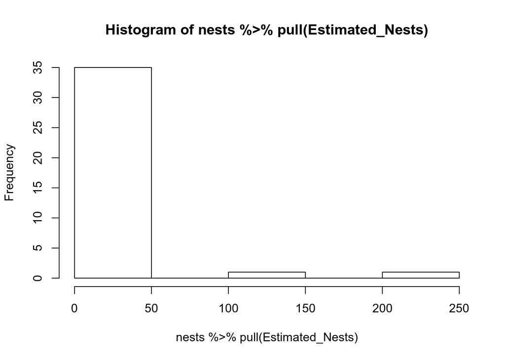

```r
hist(nests %>%
  pull(Estimated_Nests))
```

```r
shapiro.test(nests %>%
  pull(Estimated_Nests))
```

```
##
##  Shapiro-Wilk normality test
##
## data:  nests %>% pull(Estimated_Nests)
## W = 0.45358, p-value = 1.39e-10
```

The nest data was right-skewed to the right, so I asked whether the population distributions were identical using a Mann-Whitney-Wilcoxon test (Wilcoxon rank sum test). This test does not assume the data are normally distributed, but does assume the samples are independent. In order to meet the assumption that samples are independent of each other, I dropped some invasive range site-years for which we had nest estimates in more than one year.

```r
# 4 invasive range sites had counts for 2 years
n2drop <- nests %>%
  group_by(Site_Code) %>%
  dplyr::summarise(n = n()) %>%
  filter(n > 1) %>%
  pull(Site_Code) %>%
  as.character()

n2drop
```

```
## [1] "AIRP" "ELEM" "INTR" "MART"
```

```r
# Drop the 2011 estimates for these sites
nests2 <- nests %>%
  dplyr::mutate(site_year = paste(Site_Code, Year, sep = "-")) %>%
  filter(!site_year %in% paste(n2drop, "2011", sep = "-")) %>%
  droplevels() %>%
  dplyr::mutate(
    Range = factor(Range, levels = c("Native", "Invasive"))
  )
nrow(nests) - nrow(nests2)
```

```
## [1] 4
```

```r
# Checking, looks good
# nests2 %>%
#   group_by(Site_Code) %>%
#   dplyr::summarise(n = n()) %>%
#   pull(n) %>%
#   unique()
```

The mean and standard error of these filtered data per range are very similar to the full dataset.

```r
nests2 %>%
  group_by(Range) %>%
  dplyr::summarise(
    mean_nests = round(mean(Estimated_Nests), 2),
    se_nests = round(std_err(Estimated_Nests), 2)
  )
```

```
## # A tibble: 2 x 3
##   Range    mean_nests se_nests
##   <fct>         <dbl>    <dbl>
## 1 Native        36.4     12.2
## 2 Invasive       5.31     1.09
```

Mann-Whitney test with independent nest estimates. Computed exact p-values and 95% CIs to avoid using normal approximations. Unfortunately, stats::wilcox.test uses the normal approximation for data with ties, as is the case here. Used coin::wilcox_test instead, which handles data with ties and can either get the conditional null distribution by Monte Carlo resampling, or the exact distribution. The confidence intervals are for the difference in location reported below.

```r
levels(nests2$Range)
```

```
## [1] "Native"   "Invasive"
```

```r
mw_res <- wilcox_test(Estimated_Nests ~ Range, data = nests2, conf.int = TRUE, conf.level = 0.95, ties.method = "mid-ranks", alternative = "two.sided", distribution = "exact")

mw_res
```

```
##
##  Exact Wilcoxon-Mann-Whitney Test
##
## data:  Estimated_Nests by Range (Native, Invasive)
## Z = 4.2055, p-value = 2.872e-06
## alternative hypothesis: true mu is not equal to 0
## 95 percent confidence interval:
##   7 26
## sample estimates:
## difference in location
##                     14
```

# References

```
1. Smith-Vidaurre, G., Araya-Salas, M., and T.F. Wright. 2020. Individual signatures outweigh social group identity in contact calls of a communally nesting parrot. Behavioral Ecology 31(2), 448-458.

2. Buhrman-Deever, S.C., Rappaport, A.R. and J.W. Bradbury. 2007. Geographic variation in contact calls of feral North American populations of the monk parakeet. The Condor 109(2), 389-398.

3. Araya‐Salas, M., G. Smith‐Vidaurre. 2017. warbleR: An R package to streamline analysis of animal acoustic signals. Methods in Ecology and Evolution 8(2), 184-191.
```